# ESM 204 HW 4

Peter Omasta, Jennifer Truong, and Veronica Weber

5/20/2020

# **Building a Climate-Economy Model to Account For Risk and Uncertainty and Applying Sensitivity Analysis.**

### Task 1 - Plots

In order to assess economic risk and uncertainty with climate change, we needed to build a model. The first step was to create a function to factor temperature with no climate change and two “business as usual” scenarios in which temperatures reach 2 degrees Celcius (moderate climate change) and 8 degrees Celcius (extreme climate change). We used the following equation:

- Business as Usual (BAU) Temperature:
  $$\tau(t) = min(\tau(t)/100, T)$$

Next, we ran this model factoring in these three scenarios from years 0 - 200. We then placed all 3 scenario calculations into a dataframe and plotted the results.

### **A) Plotting Temperature Over Time**

- no climate change (T = 0)
- moderate climate change (T = 2)
- extreme climate change (T = 8)

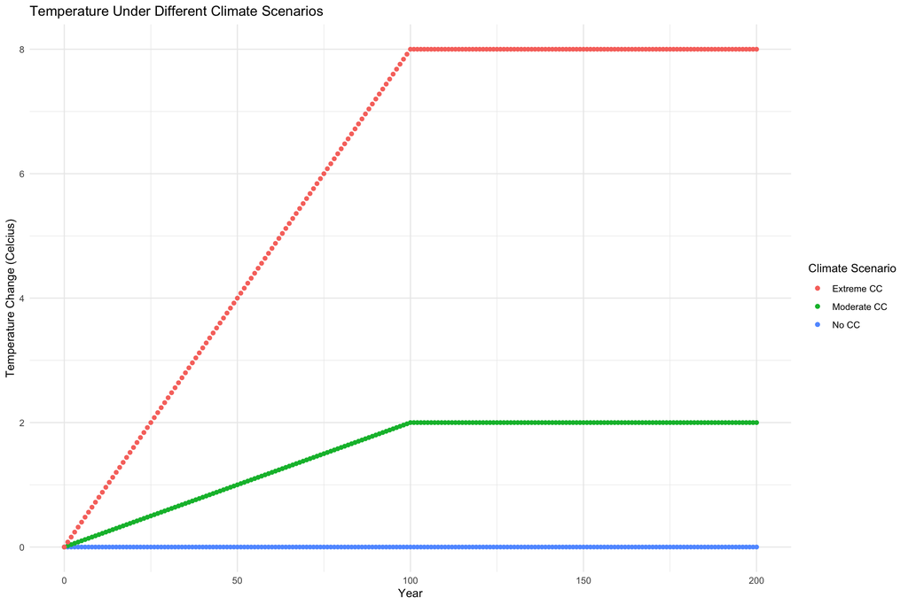

Next, we wanted to plot how economic consumption is affected over time with each of the three climate change scenarios. To do so, we created a function to factor the amount of economic activity retained as well as consumption using the following equations:

- Economic Activity Retained:
  $$K(t) = exp(-\beta*\tau(t)^2)$$
- Consumption:
  $$C(t) = K(t)exp(gt)$$

and used the following parameters:

- $\beta$ = .05.
- g = .01

### **B) Plotting Economic Consumption Over Time**

- no climate change (T = 0)
- moderate climate change (T = 2)
- extreme climate change (T = 8)

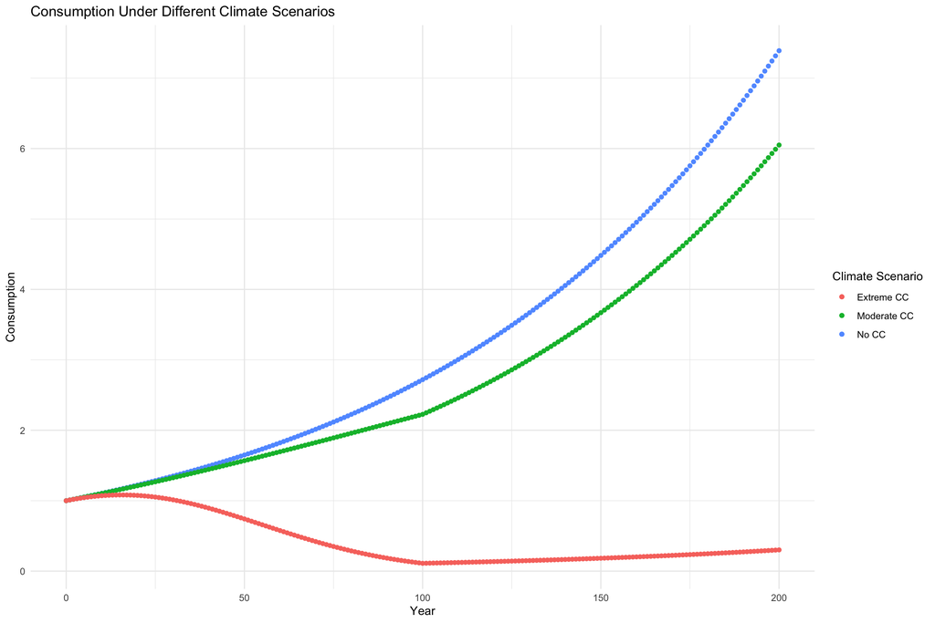

The other element we wanted to study was how undiscounted utility would change over time in the three climate change scenarios. To explore undiscounted utility we used the following equation:

- For Society’s Utility From Consumption:
  $$U(C) = C^{1-\eta}/(1-\eta)$$

and used the following parameter: $\eta$ = .5

### **C) Plotting Undiscounted Utility Over Time**

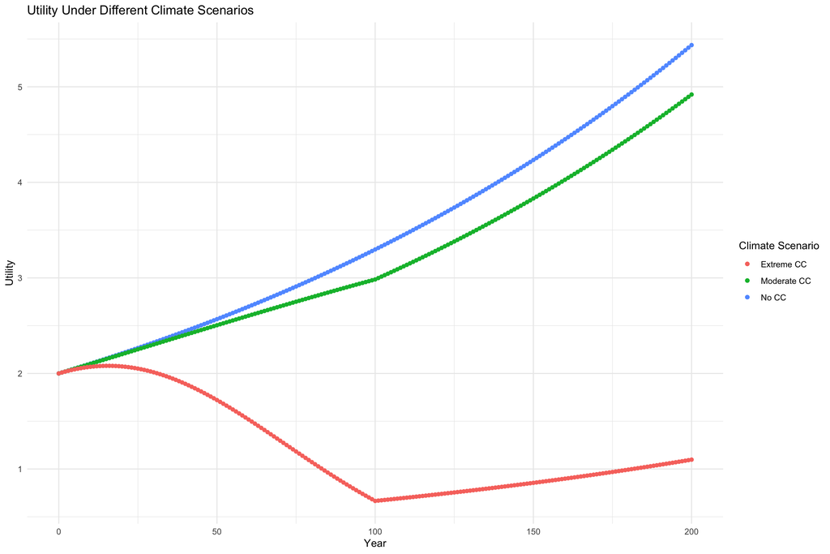

### Task 2 - Analysis

#### a) Calculating Present Value Utility with T = 4.4 and Percentage Loss

One thing we wanted to analyze was how consumers’ economic utility might change in different climate change scenarios. Suppose we knew for sure that under a BAU scenario, temperatures could reach an increase of 4.4 degrees Celcius. For this, we calculated the present value, (i.e. the discounted utility) over the next 200 years. We created a function to determine our discount rate using the Ramsey Rule equation: - r =
$$\delta + \eta*g$$

Then to find present value we used the following equation:

- Present Value Formula:
  $$v_0 = v_t/(1+r)^t$$

and we applied the following parameters for this model:

- $\delta$ = .005
- $\eta$ = .5
- g = .01
- $\beta$ = .05.

As our model shows, by year 200, present value reduces from $2 to $0.46 with climate change, and reduces from $2 to $0.74 without climate change. The total percentage loss in present value utility by year 200 is 38.37%.

### b) Sensitivity Analysis of Present Value Utility Percentage Loss

Next we wanted to test how utility may be sensitive to a number of variables in this climate change model. To test the sensitivity of values of present value utility percentage loss (L), we considered variables: temperature (T), g, $\eta$ and $\beta$ and then calculated the percent change in L that arises from a 10% increase in each:

- T = 4.4 -> 4.84
- $\eta$ = .5 -> 0.55
- g = .01 -> 0.011
- $\beta$ = .05 -> 0.055

### c) Finding The Highest Threshold of Consumption Reduction Society Is Willing to Endure Without Climate Change

The next element we considered was if we could completely prevent climate change from occurring so that temperature (T) = 0. However this would mean that economic consumption would be lessened by a fraction of $\theta$ for the next 200 years. We would need to find the maximum value of $\theta$ that society would be willing to endure, which we called $\theta$*

To do this we factored how present value utility is affected by the two climate scenarios of no climate change, when T = 0 and a BAU scenario when T = 4.4.

- No climate change but 10% reduction in consumption: $PVU(T = 0, 10\%)$
- Climate change but no reduction in consumption: $PVU(T = 4.4, 0\%)$

We then used the following formula:
$$C(t) = K(t)exp(gt)*(1-\theta)$$
To calculate $\theta$* we set the present value utility at T = 0 equal to present value utility at T = 4.4:

$PVU(T = 0, 10\%)$ equal to $PVU(T = 4.4, 0\%)$

**The value of $\theta$* that society would be willing to endure every year to prevent climate change is 3.64.**

### d) Considering Climate Uncertainty With Economic Consumption

- T = 2 (with probability .2)
- T = 4 (with probability .5)
- T = 6 (with probability .3).

After fcalculating the economic consumption and present value utilities for each climate scenario, we factored in the corresponding probabilities and added these values together to find the total expected value. We then found the minimum input values of the expected value to determine $\theta$*

**The value of $\theta$* is 0.47.**